# Risk Factor Analysis

## Outcome Variable

**Outcome Variable:** whz

## Predictor Variables

**Intervention Variable:** predfeed6

**Adjustment Set:**

unadjusted

## Stratifying Variables

The analysis was stratified on these variable(s):

- agecat
- studyid
- country

## Data Summary

| agecat | studyid | country | predfeed6 | n_cell | n |
| --- | --- | --- | --- | --- | --- |
| Birth | ki0047075b-MAL-ED | BANGLADESH | 1 | 114 | 219 |
| Birth | ki0047075b-MAL-ED | BANGLADESH | 0 | 105 | 219 |
| Birth | ki0047075b-MAL-ED | BRAZIL | 1 | 26 | 168 |
| Birth | ki0047075b-MAL-ED | BRAZIL | 0 | 142 | 168 |
| Birth | ki0047075b-MAL-ED | INDIA | 1 | 15 | 187 |
| Birth | ki0047075b-MAL-ED | INDIA | 0 | 172 | 187 |
| Birth | ki0047075b-MAL-ED | NEPAL | 1 | 22 | 165 |
| Birth | ki0047075b-MAL-ED | NEPAL | 0 | 143 | 165 |
| Birth | ki0047075b-MAL-ED | PERU | 1 | 104 | 249 |
| Birth | ki0047075b-MAL-ED | PERU | 0 | 145 | 249 |
| Birth | ki0047075b-MAL-ED | SOUTH AFRICA | 1 | 3 | 209 |
| Birth | ki0047075b-MAL-ED | SOUTH AFRICA | 0 | 206 | 209 |
| Birth | ki0047075b-MAL-ED | TANZANIA, UNITED REPUBLIC OF | 1 | 1 | 115 |
| Birth | ki0047075b-MAL-ED | TANZANIA, UNITED REPUBLIC OF | 0 | 114 | 115 |
| Birth | ki1000109-EE | PAKISTAN | 1 | 0 | 1 |
| Birth | ki1000109-EE | PAKISTAN | 0 | 1 | 1 |
| Birth | kiGH5241-JiVitA-3 | BANGLADESH | 1 | 12395 | 15420 |
| Birth | kiGH5241-JiVitA-3 | BANGLADESH | 0 | 3025 | 15420 |
| Birth | kiGH5241-JiVitA-4 | BANGLADESH | 1 | 521 | 633 |
| Birth | kiGH5241-JiVitA-4 | BANGLADESH | 0 | 112 | 633 |
| 6 months | ki0047075b-MAL-ED | BANGLADESH | 1 | 123 | 235 |
| 6 months | ki0047075b-MAL-ED | BANGLADESH | 0 | 112 | 235 |
| 6 months | ki0047075b-MAL-ED | BRAZIL | 1 | 35 | 209 |
| 6 months | ki0047075b-MAL-ED | BRAZIL | 0 | 174 | 209 |
| 6 months | ki0047075b-MAL-ED | INDIA | 1 | 18 | 232 |
| 6 months | ki0047075b-MAL-ED | INDIA | 0 | 214 | 232 |
| 6 months | ki0047075b-MAL-ED | NEPAL | 1 | 29 | 235 |
| 6 months | ki0047075b-MAL-ED | NEPAL | 0 | 206 | 235 |
| 6 months | ki0047075b-MAL-ED | PERU | 1 | 113 | 269 |
| 6 months | ki0047075b-MAL-ED | PERU | 0 | 156 | 269 |
| 6 months | ki0047075b-MAL-ED | SOUTH AFRICA | 1 | 3 | 242 |
| 6 months | ki0047075b-MAL-ED | SOUTH AFRICA | 0 | 239 | 242 |
| 6 months | ki0047075b-MAL-ED | TANZANIA, UNITED REPUBLIC OF | 1 | 2 | 244 |
| 6 months | ki0047075b-MAL-ED | TANZANIA, UNITED REPUBLIC OF | 0 | 242 | 244 |
| 6 months | ki1000109-EE | PAKISTAN | 1 | 220 | 376 |
| 6 months | ki1000109-EE | PAKISTAN | 0 | 156 | 376 |
| 6 months | ki1000304b-SAS-FoodSuppl | INDIA | 1 | 0 | 168 |
| 6 months | ki1000304b-SAS-FoodSuppl | INDIA | 0 | 168 | 168 |
| 6 months | ki1113344-GMS-Nepal | NEPAL | 1 | 404 | 546 |
| 6 months | ki1113344-GMS-Nepal | NEPAL | 0 | 142 | 546 |
| 6 months | ki1148112-LCNI-5 | MALAWI | 1 | 47 | 272 |
| 6 months | ki1148112-LCNI-5 | MALAWI | 0 | 225 | 272 |
| 6 months | kiGH5241-JiVitA-3 | BANGLADESH | 1 | 13186 | 16655 |
| 6 months | kiGH5241-JiVitA-3 | BANGLADESH | 0 | 3469 | 16655 |
| 6 months | kiGH5241-JiVitA-4 | BANGLADESH | 1 | 3331 | 4260 |
| 6 months | kiGH5241-JiVitA-4 | BANGLADESH | 0 | 929 | 4260 |
| 24 months | ki0047075b-MAL-ED | BANGLADESH | 1 | 112 | 209 |
| 24 months | ki0047075b-MAL-ED | BANGLADESH | 0 | 97 | 209 |
| 24 months | ki0047075b-MAL-ED | BRAZIL | 1 | 29 | 169 |
| 24 months | ki0047075b-MAL-ED | BRAZIL | 0 | 140 | 169 |
| 24 months | ki0047075b-MAL-ED | INDIA | 1 | 17 | 224 |
| 24 months | ki0047075b-MAL-ED | INDIA | 0 | 207 | 224 |
| 24 months | ki0047075b-MAL-ED | NEPAL | 1 | 28 | 227 |
| 24 months | ki0047075b-MAL-ED | NEPAL | 0 | 199 | 227 |
| 24 months | ki0047075b-MAL-ED | PERU | 1 | 84 | 198 |
| 24 months | ki0047075b-MAL-ED | PERU | 0 | 114 | 198 |
| 24 months | ki0047075b-MAL-ED | SOUTH AFRICA | 1 | 3 | 227 |
| 24 months | ki0047075b-MAL-ED | SOUTH AFRICA | 0 | 224 | 227 |
| 24 months | ki0047075b-MAL-ED | TANZANIA, UNITED REPUBLIC OF | 1 | 2 | 212 |
| 24 months | ki0047075b-MAL-ED | TANZANIA, UNITED REPUBLIC OF | 0 | 210 | 212 |
| 24 months | ki1113344-GMS-Nepal | NEPAL | 1 | 359 | 479 |
| 24 months | ki1113344-GMS-Nepal | NEPAL | 0 | 120 | 479 |
| 24 months | ki1148112-LCNI-5 | MALAWI | 1 | 34 | 184 |
| 24 months | ki1148112-LCNI-5 | MALAWI | 0 | 150 | 184 |
| 24 months | kiGH5241-JiVitA-3 | BANGLADESH | 1 | 6653 | 8513 |
| 24 months | kiGH5241-JiVitA-3 | BANGLADESH | 0 | 1860 | 8513 |
| 24 months | kiGH5241-JiVitA-4 | BANGLADESH | 1 | 3275 | 4159 |
| 24 months | kiGH5241-JiVitA-4 | BANGLADESH | 0 | 884 | 4159 |

The following strata were considered:

- agecat: 24 months, studyid: ki0047075b-MAL-ED, country: BANGLADESH
- agecat: 24 months, studyid: ki0047075b-MAL-ED, country: BRAZIL
- agecat: 24 months, studyid: ki0047075b-MAL-ED, country: INDIA
- agecat: 24 months, studyid: ki0047075b-MAL-ED, country: NEPAL
- agecat: 24 months, studyid: ki0047075b-MAL-ED, country: PERU
- agecat: 24 months, studyid: ki0047075b-MAL-ED, country: SOUTH AFRICA
- agecat: 24 months, studyid: ki0047075b-MAL-ED, country: TANZANIA, UNITED REPUBLIC OF
- agecat: 24 months, studyid: ki1113344-GMS-Nepal, country: NEPAL
- agecat: 24 months, studyid: ki1148112-LCNI-5, country: MALAWI
- agecat: 24 months, studyid: kiGH5241-JiVitA-3, country: BANGLADESH
- agecat: 24 months, studyid: kiGH5241-JiVitA-4, country: BANGLADESH
- agecat: 6 months, studyid: ki0047075b-MAL-ED, country: BANGLADESH
- agecat: 6 months, studyid: ki0047075b-MAL-ED, country: BRAZIL
- agecat: 6 months, studyid: ki0047075b-MAL-ED, country: INDIA
- agecat: 6 months, studyid: ki0047075b-MAL-ED, country: NEPAL
- agecat: 6 months, studyid: ki0047075b-MAL-ED, country: PERU
- agecat: 6 months, studyid: ki0047075b-MAL-ED, country: SOUTH AFRICA
- agecat: 6 months, studyid: ki0047075b-MAL-ED, country: TANZANIA, UNITED REPUBLIC OF
- agecat: 6 months, studyid: ki1000109-EE, country: PAKISTAN
- agecat: 6 months, studyid: ki1000304b-SAS-FoodSuppl, country: INDIA
- agecat: 6 months, studyid: ki1113344-GMS-Nepal, country: NEPAL
- agecat: 6 months, studyid: ki1148112-LCNI-5, country: MALAWI
- agecat: 6 months, studyid: kiGH5241-JiVitA-3, country: BANGLADESH
- agecat: 6 months, studyid: kiGH5241-JiVitA-4, country: BANGLADESH
- agecat: Birth, studyid: ki0047075b-MAL-ED, country: BANGLADESH
- agecat: Birth, studyid: ki0047075b-MAL-ED, country: BRAZIL
- agecat: Birth, studyid: ki0047075b-MAL-ED, country: INDIA
- agecat: Birth, studyid: ki0047075b-MAL-ED, country: NEPAL
- agecat: Birth, studyid: ki0047075b-MAL-ED, country: PERU
- agecat: Birth, studyid: ki0047075b-MAL-ED, country: SOUTH AFRICA
- agecat: Birth, studyid: ki0047075b-MAL-ED, country: TANZANIA, UNITED REPUBLIC OF
- agecat: Birth, studyid: ki1000109-EE, country: PAKISTAN
- agecat: Birth, studyid: kiGH5241-JiVitA-3, country: BANGLADESH
- agecat: Birth, studyid: kiGH5241-JiVitA-4, country: BANGLADESH

### Dropped Strata

Some strata were dropped due to rare outcomes:

- agecat: Birth, studyid: ki0047075b-MAL-ED, country: SOUTH AFRICA
- agecat: Birth, studyid: ki0047075b-MAL-ED, country: TANZANIA, UNITED REPUBLIC OF
- agecat: Birth, studyid: ki1000109-EE, country: PAKISTAN
- agecat: 6 months, studyid: ki0047075b-MAL-ED, country: SOUTH AFRICA
- agecat: 6 months, studyid: ki0047075b-MAL-ED, country: TANZANIA, UNITED REPUBLIC OF
- agecat: 6 months, studyid: ki1000304b-SAS-FoodSuppl, country: INDIA
- agecat: 24 months, studyid: ki0047075b-MAL-ED, country: SOUTH AFRICA
- agecat: 24 months, studyid: ki0047075b-MAL-ED, country: TANZANIA, UNITED REPUBLIC OF

## Methods Detail

We’re interested in the causal parameters $E[Y_a]$ for all values of $a \in \mathcal{A}$. These parameters represent the mean outcome if, possibly contrary to fact, we intervened to set all units to have $A=a$. Under the randomization and positivity assumptions, these are identified by the statistical parameters $\psi_a=E_W[E_{Y|A,W}(Y|A=a,W)]$. In addition, we’re interested in the mean of $Y$, $E[Y]$ under no intervention (the observed mean). We will estimate these parameters by using SuperLearner to fit the relevant likelihood factors – $E_{Y|A,W}(Y|A=a,W)$ and $p(A=a|W)$, and then updating our likelihood fit using a joint TMLE.

For unadjusted analyses ($W=\{\}$), initial likelihoods were estimated using Lrnr_glm to estimate the simple $E(Y|A)$ and Lrnr_mean to estimate $p(A)$. For adjusted analyses, a small library containing Lrnr_glmnet, Lrnr_xgboost, and Lrnr_mean was used.

Having estimated these parameters, we will then use the delta method to estimate relative risks and attributable risks relative to a prespecified baseline level of $A$.

# Results Detail

## Results Plots

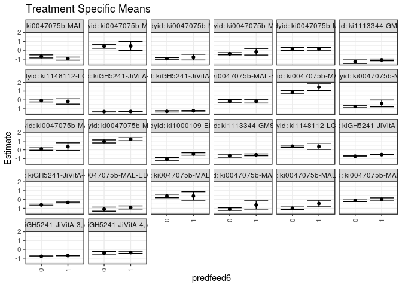

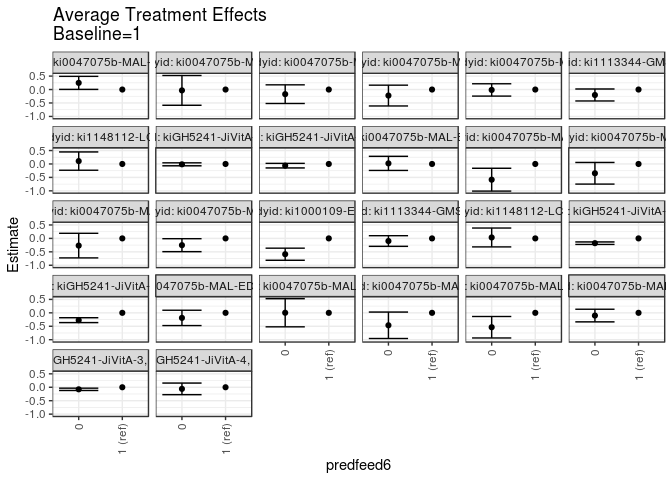

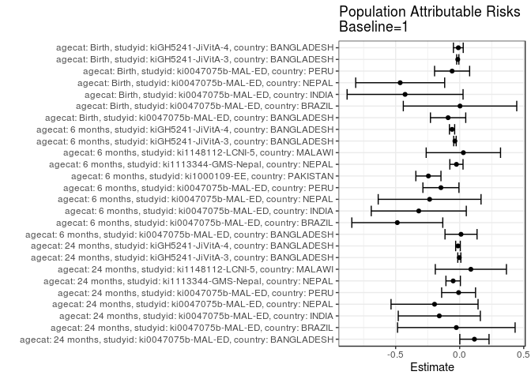

## Results Table

### Parameter: TSM

| agecat | studyid | country | intervention_level | baseline_level | estimate | ci_lower | ci_upper |
| --- | --- | --- | --- | --- | --- | --- | --- |
| Birth | ki0047075b-MAL-ED | BANGLADESH | 1 | NA | -0.9021053 | -1.0758068 | -0.7284037 |
| Birth | ki0047075b-MAL-ED | BANGLADESH | 0 | NA | -1.0906667 | -1.3179357 | -0.8633976 |
| Birth | ki0047075b-MAL-ED | BRAZIL | 1 | NA | 0.4046154 | -0.0798678 | 0.8890986 |
| Birth | ki0047075b-MAL-ED | BRAZIL | 0 | NA | 0.4078169 | 0.2085527 | 0.6070811 |
| Birth | ki0047075b-MAL-ED | INDIA | 1 | NA | -0.6173333 | -1.0860028 | -0.1486639 |
| Birth | ki0047075b-MAL-ED | INDIA | 0 | NA | -1.0807558 | -1.2294501 | -0.9320615 |
| Birth | ki0047075b-MAL-ED | NEPAL | 1 | NA | -0.4581818 | -0.8291616 | -0.0872021 |
| Birth | ki0047075b-MAL-ED | NEPAL | 0 | NA | -0.9940559 | -1.1422176 | -0.8458943 |
| Birth | ki0047075b-MAL-ED | PERU | 1 | NA | 0.0160577 | -0.1592960 | 0.1914114 |
| Birth | ki0047075b-MAL-ED | PERU | 0 | NA | -0.0855172 | -0.2416759 | 0.0706414 |
| Birth | kiGH5241-JiVitA-3 | BANGLADESH | 1 | NA | -0.7083760 | -0.7296390 | -0.6871129 |
| Birth | kiGH5241-JiVitA-3 | BANGLADESH | 0 | NA | -0.7849917 | -0.8256244 | -0.7443590 |
| Birth | kiGH5241-JiVitA-4 | BANGLADESH | 1 | NA | -0.3632821 | -0.4565978 | -0.2699665 |
| Birth | kiGH5241-JiVitA-4 | BANGLADESH | 0 | NA | -0.4232143 | -0.6180713 | -0.2283572 |
| 6 months | ki0047075b-MAL-ED | BANGLADESH | 1 | NA | -0.1569783 | -0.3442719 | 0.0303153 |
| 6 months | ki0047075b-MAL-ED | BANGLADESH | 0 | NA | -0.1349777 | -0.3188021 | 0.0488467 |
| 6 months | ki0047075b-MAL-ED | BRAZIL | 1 | NA | 1.4586667 | 1.0727188 | 1.8446145 |
| 6 months | ki0047075b-MAL-ED | BRAZIL | 0 | NA | 0.8737739 | 0.6958151 | 1.0517328 |
| 6 months | ki0047075b-MAL-ED | INDIA | 1 | NA | -0.3835185 | -0.7633878 | -0.0036492 |
| 6 months | ki0047075b-MAL-ED | INDIA | 0 | NA | -0.7297352 | -0.8612737 | -0.5981967 |
| 6 months | ki0047075b-MAL-ED | NEPAL | 1 | NA | 0.3513793 | -0.0856581 | 0.7884168 |
| 6 months | ki0047075b-MAL-ED | NEPAL | 0 | NA | 0.0837217 | -0.0523578 | 0.2198011 |
| 6 months | ki0047075b-MAL-ED | PERU | 1 | NA | 1.2017552 | 1.0316508 | 1.3718595 |
| 6 months | ki0047075b-MAL-ED | PERU | 0 | NA | 0.9494658 | 0.7783913 | 1.1205403 |
| 6 months | ki1000109-EE | PAKISTAN | 1 | NA | -0.4771591 | -0.6154207 | -0.3388974 |
| 6 months | ki1000109-EE | PAKISTAN | 0 | NA | -1.0655449 | -1.2435820 | -0.8875078 |
| 6 months | ki1113344-GMS-Nepal | NEPAL | 1 | NA | -0.5761386 | -0.6787486 | -0.4735286 |
| 6 months | ki1113344-GMS-Nepal | NEPAL | 0 | NA | -0.6736737 | -0.8424570 | -0.5048904 |
| 6 months | ki1148112-LCNI-5 | MALAWI | 1 | NA | 0.3640426 | 0.0368426 | 0.6912425 |
| 6 months | ki1148112-LCNI-5 | MALAWI | 0 | NA | 0.3987556 | 0.2722028 | 0.5253083 |
| 6 months | kiGH5241-JiVitA-3 | BANGLADESH | 1 | NA | -0.5561296 | -0.5776318 | -0.5346274 |
| 6 months | kiGH5241-JiVitA-3 | BANGLADESH | 0 | NA | -0.7340127 | -0.7761275 | -0.6918978 |
| 6 months | kiGH5241-JiVitA-4 | BANGLADESH | 1 | NA | -0.3376208 | -0.3839267 | -0.2913150 |
| 6 months | kiGH5241-JiVitA-4 | BANGLADESH | 0 | NA | -0.6108019 | -0.6899844 | -0.5316195 |
| 24 months | ki0047075b-MAL-ED | BANGLADESH | 1 | NA | -0.9466518 | -1.1191534 | -0.7741502 |
| 24 months | ki0047075b-MAL-ED | BANGLADESH | 0 | NA | -0.6987113 | -0.8698375 | -0.5275852 |
| 24 months | ki0047075b-MAL-ED | BRAZIL | 1 | NA | 0.4727586 | -0.0338175 | 0.9793347 |
| 24 months | ki0047075b-MAL-ED | BRAZIL | 0 | NA | 0.4412143 | 0.2170927 | 0.6653359 |
| 24 months | ki0047075b-MAL-ED | INDIA | 1 | NA | -0.7800000 | -1.1044915 | -0.4555085 |
| 24 months | ki0047075b-MAL-ED | INDIA | 0 | NA | -0.9521498 | -1.0740973 | -0.8302023 |
| 24 months | ki0047075b-MAL-ED | NEPAL | 1 | NA | -0.1741071 | -0.5430284 | 0.1948141 |
| 24 months | ki0047075b-MAL-ED | NEPAL | 0 | NA | -0.3979146 | -0.5157192 | -0.2801100 |
| 24 months | ki0047075b-MAL-ED | PERU | 1 | NA | 0.1514286 | -0.0046057 | 0.3074629 |
| 24 months | ki0047075b-MAL-ED | PERU | 0 | NA | 0.1367982 | -0.0319937 | 0.3055902 |
| 24 months | ki1113344-GMS-Nepal | NEPAL | 1 | NA | -1.0861096 | -1.1854287 | -0.9867904 |
| 24 months | ki1113344-GMS-Nepal | NEPAL | 0 | NA | -1.2890556 | -1.4888422 | -1.0892689 |
| 24 months | ki1148112-LCNI-5 | MALAWI | 1 | NA | -0.1644118 | -0.4639022 | 0.1350787 |
| 24 months | ki1148112-LCNI-5 | MALAWI | 0 | NA | -0.0573333 | -0.2193784 | 0.1047117 |
| 24 months | kiGH5241-JiVitA-3 | BANGLADESH | 1 | NA | -1.2963039 | -1.3227232 | -1.2698847 |
| 24 months | kiGH5241-JiVitA-3 | BANGLADESH | 0 | NA | -1.3092473 | -1.3577986 | -1.2606961 |
| 24 months | kiGH5241-JiVitA-4 | BANGLADESH | 1 | NA | -1.2205252 | -1.2576321 | -1.1834183 |
| 24 months | kiGH5241-JiVitA-4 | BANGLADESH | 0 | NA | -1.2827828 | -1.3607429 | -1.2048227 |

### Parameter: E(Y)

| agecat | studyid | country | intervention_level | baseline_level | estimate | ci_lower | ci_upper |
| --- | --- | --- | --- | --- | --- | --- | --- |
| Birth | ki0047075b-MAL-ED | BANGLADESH | NA | NA | -0.9925114 | -1.1346572 | -0.8503656 |
| Birth | ki0047075b-MAL-ED | BRAZIL | NA | NA | 0.4073214 | 0.2229599 | 0.5916830 |
| Birth | ki0047075b-MAL-ED | INDIA | NA | NA | -1.0435829 | -1.1865715 | -0.9005943 |
| Birth | ki0047075b-MAL-ED | NEPAL | NA | NA | -0.9226061 | -1.0630064 | -0.7822058 |
| Birth | ki0047075b-MAL-ED | PERU | NA | NA | -0.0430924 | -0.1600210 | 0.0738362 |
| Birth | kiGH5241-JiVitA-3 | BANGLADESH | NA | NA | -0.7234060 | -0.7433920 | -0.7034200 |
| Birth | kiGH5241-JiVitA-4 | BANGLADESH | NA | NA | -0.3738863 | -0.4580087 | -0.2897638 |
| 6 months | ki0047075b-MAL-ED | BANGLADESH | NA | NA | -0.1464929 | -0.2779745 | -0.0150113 |
| 6 months | ki0047075b-MAL-ED | BRAZIL | NA | NA | 0.9717225 | 0.8073791 | 1.1360658 |
| 6 months | ki0047075b-MAL-ED | INDIA | NA | NA | -0.7028736 | -0.8283047 | -0.5774424 |
| 6 months | ki0047075b-MAL-ED | NEPAL | NA | NA | 0.1167518 | -0.0146454 | 0.2481490 |
| 6 months | ki0047075b-MAL-ED | PERU | NA | NA | 1.0554461 | 0.9322755 | 1.1786167 |
| 6 months | ki1000109-EE | PAKISTAN | NA | NA | -0.7212766 | -0.8346857 | -0.6078675 |
| 6 months | ki1113344-GMS-Nepal | NEPAL | NA | NA | -0.6015049 | -0.6892785 | -0.5137313 |
| 6 months | ki1148112-LCNI-5 | MALAWI | NA | NA | 0.3927574 | 0.2737700 | 0.5117448 |
| 6 months | kiGH5241-JiVitA-3 | BANGLADESH | NA | NA | -0.5931801 | -0.6126929 | -0.5736674 |
| 6 months | kiGH5241-JiVitA-4 | BANGLADESH | NA | NA | -0.3971948 | -0.4378192 | -0.3565704 |
| 24 months | ki0047075b-MAL-ED | BANGLADESH | NA | NA | -0.8315789 | -0.9546058 | -0.7085521 |
| 24 months | ki0047075b-MAL-ED | BRAZIL | NA | NA | 0.4466272 | 0.2416144 | 0.6516401 |
| 24 months | ki0047075b-MAL-ED | INDIA | NA | NA | -0.9390848 | -1.0545919 | -0.8235777 |
| 24 months | ki0047075b-MAL-ED | NEPAL | NA | NA | -0.3703084 | -0.4835704 | -0.2570464 |
| 24 months | ki0047075b-MAL-ED | PERU | NA | NA | 0.1430051 | 0.0254144 | 0.2605957 |
| 24 months | ki1113344-GMS-Nepal | NEPAL | NA | NA | -1.1369520 | -1.2269975 | -1.0469065 |
| 24 months | ki1148112-LCNI-5 | MALAWI | NA | NA | -0.0771196 | -0.2204715 | 0.0662323 |
| 24 months | kiGH5241-JiVitA-3 | BANGLADESH | NA | NA | -1.2991319 | -1.3225545 | -1.2757094 |
| 24 months | kiGH5241-JiVitA-4 | BANGLADESH | NA | NA | -1.2337581 | -1.2679680 | -1.1995482 |

### Parameter: ATE

| agecat | studyid | country | intervention_level | baseline_level | estimate | ci_lower | ci_upper |
| --- | --- | --- | --- | --- | --- | --- | --- |
| Birth | ki0047075b-MAL-ED | BANGLADESH | 1 | 1 | 0.0000000 | 0.0000000 | 0.0000000 |
| Birth | ki0047075b-MAL-ED | BANGLADESH | 0 | 1 | -0.1885614 | -0.4746094 | 0.0974866 |
| Birth | ki0047075b-MAL-ED | BRAZIL | 1 | 1 | 0.0000000 | 0.0000000 | 0.0000000 |
| Birth | ki0047075b-MAL-ED | BRAZIL | 0 | 1 | 0.0032015 | -0.5206594 | 0.5270624 |
| Birth | ki0047075b-MAL-ED | INDIA | 1 | 1 | 0.0000000 | 0.0000000 | 0.0000000 |
| Birth | ki0047075b-MAL-ED | INDIA | 0 | 1 | -0.4634225 | -0.9551145 | 0.0282695 |
| Birth | ki0047075b-MAL-ED | NEPAL | 1 | 1 | 0.0000000 | 0.0000000 | 0.0000000 |
| Birth | ki0047075b-MAL-ED | NEPAL | 0 | 1 | -0.5358741 | -0.9353461 | -0.1364022 |
| Birth | ki0047075b-MAL-ED | PERU | 1 | 1 | 0.0000000 | 0.0000000 | 0.0000000 |
| Birth | ki0047075b-MAL-ED | PERU | 0 | 1 | -0.1015749 | -0.3363822 | 0.1332323 |
| Birth | kiGH5241-JiVitA-3 | BANGLADESH | 1 | 1 | 0.0000000 | 0.0000000 | 0.0000000 |
| Birth | kiGH5241-JiVitA-3 | BANGLADESH | 0 | 1 | -0.0766158 | -0.1192834 | -0.0339481 |
| Birth | kiGH5241-JiVitA-4 | BANGLADESH | 1 | 1 | 0.0000000 | 0.0000000 | 0.0000000 |
| Birth | kiGH5241-JiVitA-4 | BANGLADESH | 0 | 1 | -0.0599321 | -0.2758393 | 0.1559750 |
| 6 months | ki0047075b-MAL-ED | BANGLADESH | 1 | 1 | 0.0000000 | 0.0000000 | 0.0000000 |
| 6 months | ki0047075b-MAL-ED | BANGLADESH | 0 | 1 | 0.0220006 | -0.2404309 | 0.2844322 |
| 6 months | ki0047075b-MAL-ED | BRAZIL | 1 | 1 | 0.0000000 | 0.0000000 | 0.0000000 |
| 6 months | ki0047075b-MAL-ED | BRAZIL | 0 | 1 | -0.5848927 | -1.0098928 | -0.1598926 |
| 6 months | ki0047075b-MAL-ED | INDIA | 1 | 1 | 0.0000000 | 0.0000000 | 0.0000000 |
| 6 months | ki0047075b-MAL-ED | INDIA | 0 | 1 | -0.3462167 | -0.7482155 | 0.0557822 |
| 6 months | ki0047075b-MAL-ED | NEPAL | 1 | 1 | 0.0000000 | 0.0000000 | 0.0000000 |
| 6 months | ki0047075b-MAL-ED | NEPAL | 0 | 1 | -0.2676576 | -0.7253905 | 0.1900752 |
| 6 months | ki0047075b-MAL-ED | PERU | 1 | 1 | 0.0000000 | 0.0000000 | 0.0000000 |
| 6 months | ki0047075b-MAL-ED | PERU | 0 | 1 | -0.2522894 | -0.4935402 | -0.0110385 |
| 6 months | ki1000109-EE | PAKISTAN | 1 | 1 | 0.0000000 | 0.0000000 | 0.0000000 |
| 6 months | ki1000109-EE | PAKISTAN | 0 | 1 | -0.5883858 | -0.8138042 | -0.3629673 |
| 6 months | ki1113344-GMS-Nepal | NEPAL | 1 | 1 | 0.0000000 | 0.0000000 | 0.0000000 |
| 6 months | ki1113344-GMS-Nepal | NEPAL | 0 | 1 | -0.0975351 | -0.2950614 | 0.0999912 |
| 6 months | ki1148112-LCNI-5 | MALAWI | 1 | 1 | 0.0000000 | 0.0000000 | 0.0000000 |
| 6 months | ki1148112-LCNI-5 | MALAWI | 0 | 1 | 0.0347130 | -0.3161080 | 0.3855340 |
| 6 months | kiGH5241-JiVitA-3 | BANGLADESH | 1 | 1 | 0.0000000 | 0.0000000 | 0.0000000 |
| 6 months | kiGH5241-JiVitA-3 | BANGLADESH | 0 | 1 | -0.1778831 | -0.2241116 | -0.1316545 |
| 6 months | kiGH5241-JiVitA-4 | BANGLADESH | 1 | 1 | 0.0000000 | 0.0000000 | 0.0000000 |
| 6 months | kiGH5241-JiVitA-4 | BANGLADESH | 0 | 1 | -0.2731811 | -0.3635369 | -0.1828254 |
| 24 months | ki0047075b-MAL-ED | BANGLADESH | 1 | 1 | 0.0000000 | 0.0000000 | 0.0000000 |
| 24 months | ki0047075b-MAL-ED | BANGLADESH | 0 | 1 | 0.2479404 | 0.0049570 | 0.4909239 |
| 24 months | ki0047075b-MAL-ED | BRAZIL | 1 | 1 | 0.0000000 | 0.0000000 | 0.0000000 |
| 24 months | ki0047075b-MAL-ED | BRAZIL | 0 | 1 | -0.0315443 | -0.5854846 | 0.5223959 |
| 24 months | ki0047075b-MAL-ED | INDIA | 1 | 1 | 0.0000000 | 0.0000000 | 0.0000000 |
| 24 months | ki0047075b-MAL-ED | INDIA | 0 | 1 | -0.1721498 | -0.5187993 | 0.1744998 |
| 24 months | ki0047075b-MAL-ED | NEPAL | 1 | 1 | 0.0000000 | 0.0000000 | 0.0000000 |
| 24 months | ki0047075b-MAL-ED | NEPAL | 0 | 1 | -0.2238074 | -0.6110810 | 0.1634661 |
| 24 months | ki0047075b-MAL-ED | PERU | 1 | 1 | 0.0000000 | 0.0000000 | 0.0000000 |
| 24 months | ki0047075b-MAL-ED | PERU | 0 | 1 | -0.0146303 | -0.2444943 | 0.2152336 |
| 24 months | ki1113344-GMS-Nepal | NEPAL | 1 | 1 | 0.0000000 | 0.0000000 | 0.0000000 |
| 24 months | ki1113344-GMS-Nepal | NEPAL | 0 | 1 | -0.2029460 | -0.4260581 | 0.0201661 |
| 24 months | ki1148112-LCNI-5 | MALAWI | 1 | 1 | 0.0000000 | 0.0000000 | 0.0000000 |
| 24 months | ki1148112-LCNI-5 | MALAWI | 0 | 1 | 0.1070784 | -0.2334405 | 0.4475973 |
| 24 months | kiGH5241-JiVitA-3 | BANGLADESH | 1 | 1 | 0.0000000 | 0.0000000 | 0.0000000 |
| 24 months | kiGH5241-JiVitA-3 | BANGLADESH | 0 | 1 | -0.0129434 | -0.0676887 | 0.0418020 |
| 24 months | kiGH5241-JiVitA-4 | BANGLADESH | 1 | 1 | 0.0000000 | 0.0000000 | 0.0000000 |
| 24 months | kiGH5241-JiVitA-4 | BANGLADESH | 0 | 1 | -0.0622576 | -0.1471933 | 0.0226781 |

### Parameter: PAR

| agecat | studyid | country | intervention_level | baseline_level | estimate | ci_lower | ci_upper |
| --- | --- | --- | --- | --- | --- | --- | --- |
| Birth | ki0047075b-MAL-ED | BANGLADESH | 1 | NA | -0.0904062 | -0.2281213 | 0.0473090 |
| Birth | ki0047075b-MAL-ED | BRAZIL | 1 | NA | 0.0027060 | -0.4400812 | 0.4454932 |
| Birth | ki0047075b-MAL-ED | INDIA | 1 | NA | -0.4262496 | -0.8788627 | 0.0263636 |
| Birth | ki0047075b-MAL-ED | NEPAL | 1 | NA | -0.4644242 | -0.8117540 | -0.1170945 |
| Birth | ki0047075b-MAL-ED | PERU | 1 | NA | -0.0591501 | -0.1960273 | 0.0777272 |
| Birth | kiGH5241-JiVitA-3 | BANGLADESH | 1 | NA | -0.0150300 | -0.0234273 | -0.0066327 |
| Birth | kiGH5241-JiVitA-4 | BANGLADESH | 1 | NA | -0.0106041 | -0.0488339 | 0.0276257 |
| 6 months | ki0047075b-MAL-ED | BANGLADESH | 1 | NA | 0.0104854 | -0.1145963 | 0.1355671 |
| 6 months | ki0047075b-MAL-ED | BRAZIL | 1 | NA | -0.4869442 | -0.8420146 | -0.1318738 |
| 6 months | ki0047075b-MAL-ED | INDIA | 1 | NA | -0.3193550 | -0.6903566 | 0.0516466 |
| 6 months | ki0047075b-MAL-ED | NEPAL | 1 | NA | -0.2346275 | -0.6360327 | 0.1667776 |
| 6 months | ki0047075b-MAL-ED | PERU | 1 | NA | -0.1463091 | -0.2870087 | -0.0056095 |
| 6 months | ki1000109-EE | PAKISTAN | 1 | NA | -0.2441175 | -0.3421368 | -0.1460982 |
| 6 months | ki1113344-GMS-Nepal | NEPAL | 1 | NA | -0.0253663 | -0.0768630 | 0.0261305 |
| 6 months | ki1148112-LCNI-5 | MALAWI | 1 | NA | 0.0287148 | -0.2614906 | 0.3189202 |
| 6 months | kiGH5241-JiVitA-3 | BANGLADESH | 1 | NA | -0.0370505 | -0.0467033 | -0.0273978 |
| 6 months | kiGH5241-JiVitA-4 | BANGLADESH | 1 | NA | -0.0595740 | -0.0800196 | -0.0391284 |
| 24 months | ki0047075b-MAL-ED | BANGLADESH | 1 | NA | 0.1150728 | 0.0010555 | 0.2290902 |
| 24 months | ki0047075b-MAL-ED | BRAZIL | 1 | NA | -0.0261314 | -0.4850203 | 0.4327575 |
| 24 months | ki0047075b-MAL-ED | INDIA | 1 | NA | -0.1590848 | -0.4794820 | 0.1613124 |
| 24 months | ki0047075b-MAL-ED | NEPAL | 1 | NA | -0.1962012 | -0.5358409 | 0.1434385 |
| 24 months | ki0047075b-MAL-ED | PERU | 1 | NA | -0.0084235 | -0.1407733 | 0.1239262 |
| 24 months | ki1113344-GMS-Nepal | NEPAL | 1 | NA | -0.0508424 | -0.1072901 | 0.0056053 |
| 24 months | ki1148112-LCNI-5 | MALAWI | 1 | NA | 0.0872922 | -0.1903700 | 0.3649544 |
| 24 months | kiGH5241-JiVitA-3 | BANGLADESH | 1 | NA | -0.0028280 | -0.0147863 | 0.0091303 |
| 24 months | kiGH5241-JiVitA-4 | BANGLADESH | 1 | NA | -0.0132329 | -0.0313525 | 0.0048866 |